# Jobs Report End to End

### Import data via FRED and BLS

One of the great things about R is that packages have been built to help us with a lot of tasks.

We will use tq.get() from the `tidyquant` package to retrieve data from FRED. First, we need to indicate what data we want.

```r
fred_codes <- c(
            "CIVPART",
            "EMRATIO",
            "NROU",
            "UNRATE",
            "CES0500000003",
            "AWHAETP",
            "NPPTTL",
            "PAYEMS",
            "USCONS",
            "USTRADE",
            "USPBS",
            "MANEMP",
            "USFIRE",
            "USMINE",
            "USEHS",
            "USWTRADE",
            "CES4349300001",
            "USINFO",
            "USLAH",
            "USGOVT",
            "USSERV")

column_names <- c(
            "date",
            "Labor Force Part Rate",
            "Employment-to-Pop Ratio",
            "Nat Rate Unemployment",
            "Unemployment Rate",
            "Avg Hourly Earnings",
            "Avg Weekly Hours",
            "ADP Estimate",
            "Nonfarm Employment",
            "Construction",
            "Retail/Trade",
            "Prof/Bus Serv",
            "Manufact",
            "Financial",
            "Mining",
            "Health Care",
            "Wholesale Trade",
            "Transportation",
            "Info Sys",
            "Leisure",
            "Gov",
            "Other Services")

library(tidyquant)
# download data via FRED by using tidyquant
fred_empl_data <-
  tq_get(fred_codes,
         get = "economic.data",
         from = "1980-01-01")
```

Let’s go get some BLS data that for whatever reason FRED doesn’t include. In this case, labor force participation rate for the working age population age 25-54, and then for men and women.

```r
# download data direct from BLS
# use the 'import dataset' button in RStudio to experiment with how to get this data
# into a good, importable format
bls_labor_for_data <-
  read_delim("https://download.bls.gov/pub/time.series/ln/ln.data.1.AllData",
             "\t",
             escape_double = FALSE,
             col_types = cols(
               value = col_character(),
               footnote_codes = col_skip()),
             trim_ws = TRUE,
             progress = FALSE)
```

We just imported 6.3 million rows and every time series that BLS has available. But we want to work with just three. Let use `filter` from `dplyr` by series_id to get just our desired rows, then use `parse_date_time` from the `lubridate` package to create a nicer date. We will use `mutate` and `case_when` from `dplyr` to create a column of demographic categories.

```r
bls_labor_wrangled <-
  bls_labor_for_data %>%
  filter(series_id == "LNS11300060"|
        series_id == "LNS11300061" |
        series_id == "LNS11300062") %>%
  mutate(date = ymd(parse_date_time(paste0(year, period), "%Y%m")),
         dem = case_when(series_id == "LNS11300060" ~ "All",
                         series_id == "LNS11300061" ~ "Men",
                         series_id == "LNS11300062" ~ "Women"),
         value = as.numeric(value)) %>%
  filter(date >= "1980-01-01") %>%
  select(date, everything(), -year, -period, -series_id)
```

### API

We might want to use an API like Energy Information Administration (www.eia.gov). All the data is public available through their OpenData platform. Anyone can acquire a free token and access all of their public data sets.

```r
library(rjson)
library(RJSONIO)

# code for gas storage all USA
code <-   "NG.NW2_EPG0_SWO_R48_BCF.W"

fromJSON(paste0(
    "http://api.eia.gov/series/?api_key=B0EDABE19140380774029141270387BE&series_id=",
    code,
    "&format=json")) %>%
  pluck("series", 1, "data") %>%
  transpose() %>%
  `names<-`(c("date", "value")) %>%
  simplify_all() %>%
  as_tibble() %>%
  mutate(date = ymd(date)) %>%
  arrange(date)
```

| date | value |
| --- | --- |
| 2010-01-01 | 3117 |
| 2010-01-08 | 2850 |
| 2010-01-15 | 2607 |
| 2010-01-22 | 2521 |
| 2010-01-29 | 2406 |
| 2010-02-05 | 2214 |
| 2010-02-12 | 2026 |
| 2010-02-19 | 1853 |
| 2010-02-26 | 1738 |
| 2010-03-05 | 1627 |

[output cut: 435 more lines]

```r
eia_df_gasstorage <-
tribble(
  ~ticker, ~location,
  "NG.NW2_EPG0_SWO_R48_BCF.W", "US",
  "NG.NW2_EPG0_SWO_R31_BCF.W", "East",
  "NG.NW2_EPG0_SWO_R32_BCF.W", "Midwest",
  "NG.NW2_EPG0_SWO_R35_BCF.W", "Pacific",
  "NG.NW2_EPG0_SWO_R33_BCF.W", "South"
  )

# best is to wrap to function when done
eia_grab_func <- function(code) {
  fromJSON(paste0(
    "http://api.eia.gov/series/?api_key=B0EDABE19140380774029141270387BE&series_id=",
    code,
    "&format=json")) %>%
  pluck("series", 1, "data") %>%
  transpose() %>%
  `names<-`(c("date", "value")) %>%
  simplify_all() %>%
  as_tibble() %>%
  mutate(date = ymd(date)) %>%
  arrange(date)
}

eia_df_gasstorage %>%
  mutate(data = map(ticker, eia_grab_func)) %>%
  unnest() %>%
  head()
```

| ticker | location | date | value |
| --- | --- | --- | --- |
| NG.NW2_EPG0_SWO_R48_BCF.W | US | 2010-01-01 | 3117 |
| NG.NW2_EPG0_SWO_R48_BCF.W | US | 2010-01-08 | 2850 |
| NG.NW2_EPG0_SWO_R48_BCF.W | US | 2010-01-15 | 2607 |
| NG.NW2_EPG0_SWO_R48_BCF.W | US | 2010-01-22 | 2521 |
| NG.NW2_EPG0_SWO_R48_BCF.W | US | 2010-01-29 | 2406 |
| NG.NW2_EPG0_SWO_R48_BCF.W | US | 2010-02-05 | 2214 |

### Visualizations

We will use just the BLS data from here.

First, a `ggplot` recession object.

```r
# a quick ggplot recessions data code flow
recessions_tribble <- tribble(
  ~Peak, ~Trough,
  "1948-11-01", "1949-10-01",
  "1953-07-01", "1954-05-01",
  "1957-08-01", "1958-04-01",
  "1960-04-01", "1961-02-01",
  "1969-12-01", "1970-11-01",
  "1973-11-01", "1975-03-01",
  "1980-01-01", "1980-07-01",
  "1981-07-01", "1982-11-01",
  "1990-07-01", "1991-03-01",
  "2001-03-01", "2001-11-01",
  "2007-12-01", "2009-06-01") %>%
  mutate(Peak = ymd(Peak),
         Trough = ymd(Trough))

# can save ggplot variables
# geom_rect creates that object
recession_shade <-
  geom_rect(data = recessions_tribble,
            inherit.aes = F,
            aes(xmin = Peak,
                xmax = Trough,
                ymin = -Inf,
                ymax = +Inf),
            fill = 'darkgray',
            alpha = 0.4)
```

Now we visualize our three data sets over time. `ggplot` can color each time series uniqely since we tell it to `group_by` the `dem` column. We add our recessions object that was created in the above code chunk.

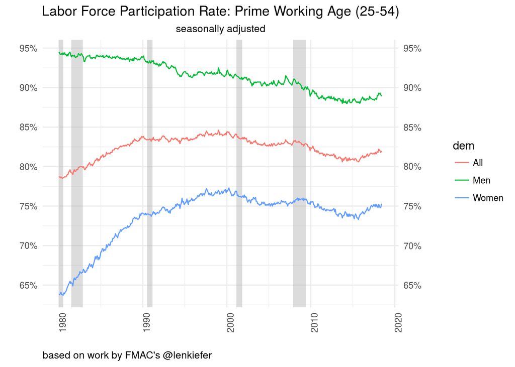

```r
bls_labor_wrangled %>%
  group_by(dem) %>%
  ggplot(aes(x = date,
             y = value,
             color = dem,
             label = dem)) +
  recession_shade +
  geom_line()  +
  theme_minimal() +
  xlim(ymd("1980-01-01"), Sys.Date()) +
  scale_y_continuous(breaks = scales::pretty_breaks(n = 10),
                     labels = function(x) paste0(x, "%"),
                     sec.axis = dup_axis()) +
  theme(axis.text.x = element_text(angle = 90, hjust = 1),
        plot.title = element_text(hjust = 0.5),
        plot.subtitle = element_text(hjust = 0.5),
        plot.caption=element_text(hjust=0)) +
  ylab("") +
  xlab("") +
  ggtitle("Labor Force Participation Rate: Prime Working Age (25-54)",
          subtitle = "seasonally adjusted") +
  labs(caption = "based on work by FMAC's @lenkiefer")
```

### Convert to xts

A different data format, sometimes needed for visualizations or models. We will convert our data to an `xts` object. XTS stands for extensible time series. Note there is not date ‘column’, it’s a date index. If we remove that index, it’s no longer an `xts` object, it reverts to a matrix.

Our conversion is done with the `tk_xts` function from the `timetk` package.

```r
library(timetk)

bls_labor_xts <-
  bls_labor_wrangled%>%
  group_by(dem) %>%
  spread(dem, value) %>%
  tk_xts(date_var = date)
```

### Visualize xts with highcharter

highcharter is an R hook into the highcarts javascript library. Similar js hooks are available through the `dygraphs` and `plotly` packages.

```r
library(highcharter)


highchart(type = 'stock')%>%
  hc_add_series(bls_labor_xts$All, name = "All") %>%
  hc_add_series(bls_labor_xts$Men, name = "Men") %>%
  hc_add_series(bls_labor_xts$Women, name = "Women") %>%
  hc_title(text = "Labor Force Participation (age 25-54") %>%
      hc_xAxis(type = 'datetime',
                 plotBands = list(
                   list(
                     label = list(text = "Bush Senior"),
                     color = "rgba(100, 0, 0, 0.1)",
                     from = datetime_to_timestamp(as.Date('1990-07-01', tz = 'UTC')),
                     to = datetime_to_timestamp(as.Date('1991-03-01', tz = 'UTC'))
                     ),
                   list(
                     label = list(text = "Internet Bubble"),
                     color = "rgba(100, 0, 0, 0.1)",
                     from = datetime_to_timestamp(as.Date('2001-03-01', tz = 'UTC')),
                     to = datetime_to_timestamp(as.Date('2001-11-01', tz = 'UTC'))
                     ),
                   list(
                     label = list(text = "Financial Crisis"),
                     color = "rgba(100, 0, 0, 0.1)",
                     from = datetime_to_timestamp(as.Date('2007-12-01', tz = 'UTC')),
                     to = datetime_to_timestamp(as.Date('2009-06-01', tz = 'UTC'))
                     ),
                   list(
                     label = list(text = "Volker Fed"),
                     color = "rgba(100, 0, 0, 0.1)",
                     from = datetime_to_timestamp(as.Date('1981-07-01', tz = 'UTC')),
                     to = datetime_to_timestamp(as.Date('1982-11-01', tz = 'UTC'))
                     )
                   )
               ) %>%
  hc_navigator(enabled = FALSE) %>%
  hc_scrollbar(enabled = FALSE) %>%
  hc_legend(enabled = TRUE) %>%
  hc_exporting(enabled = TRUE)
```

[interactive chart not shown]

### Convert to TS

Now let’s do some modeling and forecasting using the `forecast` package. The `forecast` functions want data in yet another format, that of `ts`. So, we need to convert again with the `tk_ts` function from `timetk`. We will go to quarterly data.

```r
bls_all_ts <-
  bls_labor_wrangled %>%
  filter(date >= "1990-01-01") %>%
  filter(dem == "All") %>%
  tq_transmute(mutate_fun = to.period, period = "quarters") %>%
    tk_ts(select = -date, start = c(1990, 3), freq = 4)
```

### Model and forecast as arima, then ets, then bats.

We will use the build in models from the forecast package but can use custom or other models too.

### Auto Arima model

```r
library(forecast)
auto.arima(bls_all_ts) %>%
  forecast() %>%
  hchart()
```

[interactive chart not shown]

### ETS model

```r
ets(bls_all_ts, damped = TRUE) %>%
  forecast()%>%
  hchart()
```

[interactive chart not shown]

### Bats model

```r
bats(bls_all_ts) %>%
  forecast()%>%
  hchart()
```

[interactive chart not shown]

### 3 Models, one piped workflow

First create a list of models, and nest our `ts` data as list inside those lists.

```r
fcast_model_list <- list(
    auto.arima = list(
        y = bls_all_ts
        ),
    ets = list(
        y = bls_all_ts,
        damped = TRUE
    ),
    bats = list(
        y = bls_all_ts
    )
)
```

Use `enframe` from the `tibble` package to turn our list of functions into a data frame.

```r
fcast_model_tbl <-
  enframe(fcast_model_list,
          name = "func",
          value = "params")

fcast_model_tbl
```

| func | params |
| --- | --- |
| auto.arima |  |
| ets |  |
| bats |  |

Now let’s run our models in one piped workflow, using `invoke_map` and `map` from `purrr`, and `tidy` from the `broom` package to clean up the results.

```r
library(broom)

fcast_model_tbl %>%
  mutate(modeled = invoke_map(func, params)) %>%
  mutate(forecasted = map(modeled, forecast, h = 4)) %>%
  mutate(tidied = map(forecasted, tidy)) %>%
  unnest(tidied)
```

| func | Point Forecast | Lo 80 | Hi 80 | Lo 95 | Hi 95 |
| --- | --- | --- | --- | --- | --- |
| auto.arima | 82.06450 | 81.80227 | 82.32673 | 81.66345 | 82.46555 |
| auto.arima | 82.18267 | 81.86392 | 82.50143 | 81.69518 | 82.67017 |
| auto.arima | 81.98246 | 81.63015 | 82.33477 | 81.44365 | 82.52128 |
| auto.arima | 82.08087 | 81.66318 | 82.49856 | 81.44207 | 82.71968 |
| ets | 82.11232 | 81.84642 | 82.37822 | 81.70566 | 82.51898 |
| ets | 82.16639 | 81.87419 | 82.45860 | 81.71950 | 82.61329 |
| ets | 82.21250 | 81.88022 | 82.54478 | 81.70432 | 82.72068 |
| ets | 82.25180 | 81.86912 | 82.63448 | 81.66655 | 82.83705 |
| bats | 82.11295 | 81.84303 | 82.38288 | 81.70014 | 82.52577 |
| bats | 82.16770 | 81.86758 | 82.46782 | 81.70871 | 82.62670 |

[output cut: 2 more lines]

Try to visualize those results - there is no unified structure. Can’t do it!

### Sweep the data

the `sweep` package was built to tidy up time series models and forecasts. Let’s use the `sw_sweep` function.

```r
library(sweep)

fcast_model_tbl %>%
mutate(modeled = invoke_map(func, params)) %>%
mutate(forecasted = map(modeled, forecast, h = 10)) %>%
mutate(swept = map(forecasted,
                   sw_sweep,
                   fitted = FALSE,
                   timetk_idx = TRUE,
                   rename_index = "date")) %>%
unnest(swept)
```

| func | date | key | value | lo.80 | lo.95 | hi.80 | hi.95 |
| --- | --- | --- | --- | --- | --- | --- | --- |
| auto.arima | 1990-03-01 | actual | 83.60000 | NA | NA | NA | NA |
| auto.arima | 1990-06-01 | actual | 83.40000 | NA | NA | NA | NA |
| auto.arima | 1990-09-01 | actual | 83.40000 | NA | NA | NA | NA |
| auto.arima | 1990-12-01 | actual | 83.40000 | NA | NA | NA | NA |
| auto.arima | 1991-03-01 | actual | 83.40000 | NA | NA | NA | NA |
| auto.arima | 1991-06-01 | actual | 83.40000 | NA | NA | NA | NA |
| auto.arima | 1991-09-01 | actual | 83.40000 | NA | NA | NA | NA |
| auto.arima | 1991-12-01 | actual | 83.20000 | NA | NA | NA | NA |
| auto.arima | 1992-03-01 | actual | 83.50000 | NA | NA | NA | NA |
| auto.arima | 1992-06-01 | actual | 83.90000 | NA | NA | NA | NA |

[output cut: 362 more lines]

### It’s tidy, let’s use ggplot for visualizations

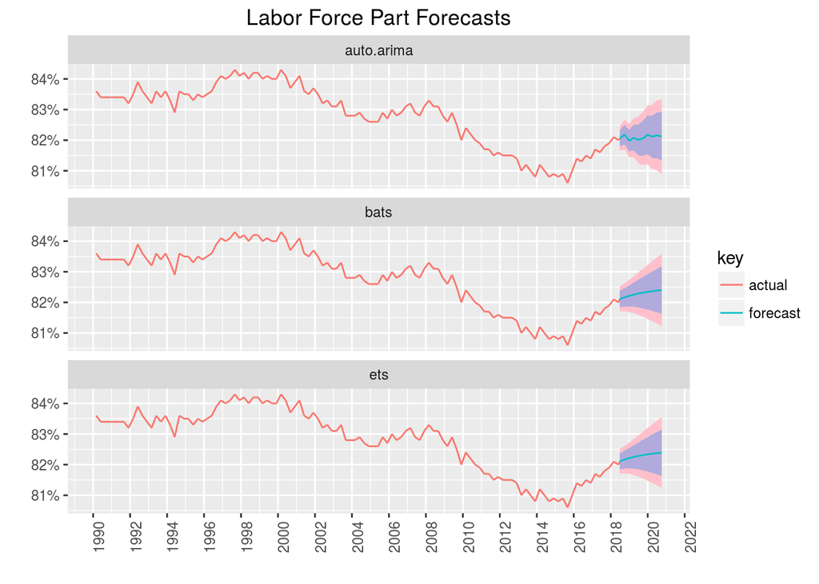

```r
fcast_model_tbl %>%
mutate(modeled = invoke_map(func, params)) %>%
mutate(forecasted = map(modeled, forecast, h = 10)) %>%
mutate(swept = map(forecasted,
                   sw_sweep,
                   fitted = FALSE,
                   timetk_idx = TRUE,
                   rename_index = "date")) %>%
unnest(swept) %>%
ggplot(aes(x = date,
           y = value,
           color = key,
           group = func)) +
    geom_ribbon(aes(ymin = lo.95,
                    ymax = hi.95),
                fill = "pink",
                color = NA,
                size = 0) +
    geom_ribbon(aes(ymin = lo.80,
                    ymax = hi.80),
                fill = "cornflowerblue",
                color = NA,
                size = 0,
                alpha = 0.5) +
    geom_line() +
    facet_wrap(~func, nrow = 3) +
  labs(title = "Labor Force Part Forecasts",
       x = "",
       y = "") +
  scale_y_continuous(labels = function(x) paste0(x, "%")) +
  scale_x_date(breaks = scales::pretty_breaks(n = 15)) +
  theme(axis.text.x = element_text(angle = 90, hjust = 1),
        plot.title = element_text(hjust = 0.5))
```

### Rolling Standard Deviation by group

There was a question about rolling volatility by group.

```r
# The symbols vector holds our tickers.
symbols <- c("SPY","EFA", "IJS", "EEM","AGG")

 etf_returns <-
   symbols %>%
   # get prices from yahoo
   tq_get(get  = "stock.prices",
           from = "2011-12-31",
           to   = "2017-12-31") %>%
    group_by(symbol) %>%
    # convert to monthly returns
    tq_transmute(select     = adjusted,
                 mutate_fun = periodReturn,
                 period     = "monthly",
                 col_rename = "monthly_returns")
 etf_returns
```

| symbol | date | monthly_returns |
| --- | --- | --- |
| SPY | 2012-01-31 | 2.996091e-02 |
| SPY | 2012-02-29 | 4.340561e-02 |
| SPY | 2012-03-30 | 3.216329e-02 |
| SPY | 2012-04-30 | -6.675460e-03 |
| SPY | 2012-05-31 | -6.005578e-02 |
| SPY | 2012-06-29 | 4.058115e-02 |
| SPY | 2012-07-31 | 1.182928e-02 |
| SPY | 2012-08-31 | 2.505288e-02 |
| SPY | 2012-09-28 | 2.535112e-02 |
| SPY | 2012-10-31 | -1.819851e-02 |

[output cut: 350 more lines]

Have a look at the data. It’s monthly returns for each ETF, grouped by the ETF symbol. Now we can run calculations on a group by group basis.

Two ways to do so:

1. use the built in functionality from `tidyquant`, which wraps `rollapply` and the `sd` function and allows us to apply to a tidy tibble.

```r
# width = the rolling window
etf_returns %>%
  tq_mutate(mutate_fun = rollapply,
            width = 6,
            FUN = sd,
            col_rename = "rolling_sd") %>%
  select(date, rolling_sd)
```

| symbol | date | rolling_sd |
| --- | --- | --- |
| SPY | 2012-01-31 | NA |
| SPY | 2012-02-29 | NA |
| SPY | 2012-03-30 | NA |
| SPY | 2012-04-30 | NA |
| SPY | 2012-05-31 | NA |
| SPY | 2012-06-29 | 0.040159877 |
| SPY | 2012-07-31 | 0.039322571 |
| SPY | 2012-08-31 | 0.036860481 |
| SPY | 2012-09-28 | 0.036031504 |
| SPY | 2012-10-31 | 0.037133371 |

[output cut: 350 more lines]

That method works very well. Let’s see how to do the same with `tibbletime`

First create our own rolling function using `rollify` from the `tibbletime` package.

```r
library(tibbletime)
sd_roll_6 <-
  rollify(sd, window = 6)
```

Now convert `etf_returns` to a `tibbletime` object and apply that function.

```r
etf_returns %>%
  as_tbl_time(index = date) %>%
  mutate(sd = sd_roll_6(monthly_returns)) %>%
  select(-monthly_returns)
```

| symbol | date | sd |
| --- | --- | --- |
| SPY | 2012-01-31 | NA |
| SPY | 2012-02-29 | NA |
| SPY | 2012-03-30 | NA |
| SPY | 2012-04-30 | NA |
| SPY | 2012-05-31 | NA |
| SPY | 2012-06-29 | 0.040159877 |
| SPY | 2012-07-31 | 0.039322571 |
| SPY | 2012-08-31 | 0.036860481 |
| SPY | 2012-09-28 | 0.036031504 |
| SPY | 2012-10-31 | 0.037133371 |

[output cut: 350 more lines]

Those two methods got us the same result, which one is better? Well, the first method is a bit easier because we didn’t need to create our own rolling function. The second method is more flexible - we can create whatever rolling function we want and apply it to a tibbletime object.